# Simulation Argument Details for `simglm`

2026-09-01

The tidy simulation framework uses simulation arguments as the basis for specifying the models to be simulated. The goal of this vignette is to document more thoroughly the various arguments that are possible within each function. It is recommended that new users start with the “Tidy Simulation with `simglm`” vignette prior to working through this vignette.

# Fixed Arguments

Arguments associated with the fixed portion of the model are needed for each fixed variable that needs to be simulated. The fixed variables specified come from the formula argument. Interactions or the intercept are not included in the fixed arguments as these are generated automatically. Let’s start with an example.

```r
library(simglm)

set.seed(321)

# To-DO: Add knot variable and debug

sim_arguments <- list(
  formula = y ~ 1 + time + weight + age + treat + (1 + time| id),
  fixed = list(time = list(var_type = 'time'),
               weight = list(var_type = 'continuous', mean = 180, sd = 30),
               age = list(var_type = 'ordinal', levels = 30:60, var_level = 2),
               treat = list(var_type = 'factor',
                            levels = c('Treatment', 'Control'),
                            var_level = 2)),
  sample_size = list(level1 = 10, level2 = 20)
)

fixed_data <- simulate_fixed(data = NULL, sim_arguments)
head(fixed_data, n = 20)
```

```
##    X.Intercept. time   weight age treat_1   treat level1_id id
## 1             1    0 231.1471  39       1 Control         1  1
## 2             1    1 158.6388  39       1 Control         2  1
## 3             1    2 171.6605  39       1 Control         3  1
## 4             1    3 176.4105  39       1 Control         4  1
## 5             1    4 176.2812  39       1 Control         5  1
## 6             1    5 188.0455  39       1 Control         6  1
## 7             1    6 201.8052  39       1 Control         7  1
## 8             1    7 186.9941  39       1 Control         8  1
## 9             1    8 190.1734  39       1 Control         9  1
## 10            1    9 163.4426  39       1 Control        10  1
## 11            1    0 190.4310  30       1 Control         1  2
## 12            1    1 224.5378  30       1 Control         2  2
## 13            1    2 185.6498  30       1 Control         3  2
## 14            1    3 253.2978  30       1 Control         4  2
## 15            1    4 145.3968  30       1 Control         5  2
## 16            1    5 155.8598  30       1 Control         6  2
## 17            1    6 193.6821  30       1 Control         7  2
## 18            1    7 192.6100  30       1 Control         8  2
## 19            1    8 197.3275  30       1 Control         9  2
## 20            1    9 193.3907  30       1 Control        10  2
```

- ‘time’: This type of variable is used for a time metric variable
- ‘continuous’: This is a continuous distribution, default is to use the `rnorm` distribution function for generation.
- ‘ordinal’: This generates ordinal data and is generated using the `sample` function.
- ‘factor’: This is a categorical or factor variable specification representing groups or categories.
- ‘knot’: This type of variable is generated based on another variable and represents a knot category variable.

Each variable type will be explored in more detail.

Finally, another common argument for all fixed variable types is the argument `var_level`. This defaults to `var_level = 1` which would be a variable defined at the level 1 of the model (i.e. unique value for each row in the data). These can be changed to reflect the data level that is desired. For example, `var_level = 2` would repeat values for each level 2 cluster found in the data and `var_level = 3` would do the same for each level 3 cluster. Therefore for variables that are at level 2 or level 3, there will be fewer unique values in the data compared to level 1 variables.

## Time Variable

For time variables used in longitudinal or repeated measures designs, the default metric is 0 to level1 sample size minus 1. This can be seen above in the output. To change the time variable metric the `time_levels` argument can be used. A vector of values to specify for the time variable can be given directly. For example, the following could be passed to alter the metric of the time variable: `time_levels = c(0, 0.5, 1, 1.5, 2, 2.5, 3, 4, 5, 6)` where now the time variable would increment in 0.5 units for the first 7 measurements and 1 unit increments for the last three measurements. This could represent a case when the measurements are collected every 6 months for the first 7 measurements and yearly after that.

Below is the output including the manual time variable specification. The only requirement is that the length of the `time_levels` argument must match the level1 sample size.

```r
set.seed(321)

# To-DO: Add knot variable and debug

sim_arguments <- list(
  formula = y ~ 1 + time + weight + age + treat + (1 + time| id),
  fixed = list(time = list(var_type = 'time',
                           time_levels = c(0, 0.5, 1, 1.5, 2, 2.5, 3, 4, 5, 6)),
               weight = list(var_type = 'continuous', mean = 180, sd = 30),
               age = list(var_type = 'ordinal', levels = 30:60, var_level = 2),
               treat = list(var_type = 'factor',
                            levels = c('Treatment', 'Control'),
                            var_level = 2)),
  sample_size = list(level1 = 10, level2 = 20)
)

fixed_data <- simulate_fixed(data = NULL, sim_arguments)
head(fixed_data, n = 20)
```

```
##    X.Intercept. time   weight age treat_1   treat level1_id id
## 1             1  0.0 231.1471  39       1 Control         1  1
## 2             1  0.5 158.6388  39       1 Control         2  1
## 3             1  1.0 171.6605  39       1 Control         3  1
## 4             1  1.5 176.4105  39       1 Control         4  1
## 5             1  2.0 176.2812  39       1 Control         5  1
## 6             1  2.5 188.0455  39       1 Control         6  1
## 7             1  3.0 201.8052  39       1 Control         7  1
## 8             1  4.0 186.9941  39       1 Control         8  1
## 9             1  5.0 190.1734  39       1 Control         9  1
## 10            1  6.0 163.4426  39       1 Control        10  1
## 11            1  0.0 190.4310  30       1 Control         1  2
## 12            1  0.5 224.5378  30       1 Control         2  2
## 13            1  1.0 185.6498  30       1 Control         3  2
## 14            1  1.5 253.2978  30       1 Control         4  2
## 15            1  2.0 145.3968  30       1 Control         5  2
## 16            1  2.5 155.8598  30       1 Control         6  2
## 17            1  3.0 193.6821  30       1 Control         7  2
## 18            1  4.0 192.6100  30       1 Control         8  2
## 19            1  5.0 197.3275  30       1 Control         9  2
## 20            1  6.0 193.3907  30       1 Control        10  2
```

## Continuous Variable

Continuous variables are generating using distribution functions (i.e. `rnorm`). Any distribution function found within R, or user written distribution functions can be used, however the default used in `rnorm`. To change the distribution function used, the argument `dist` can be specified. For example, if the Gamma distribution is desired for the weight variable, the following code would achieve this:

```r
set.seed(321)

sim_arguments <- list(
  formula = y ~ 1 + time + weight + age + treat + (1 + time| id),
  fixed = list(time = list(var_type = 'time',
                           time_levels = c(0, 0.5, 1, 1.5, 2, 2.5, 3, 4, 5, 6)),
               weight = list(var_type = 'continuous', dist = 'rgamma',
                             shape = 3),
               age = list(var_type = 'ordinal', levels = 30:60, var_level = 2),
               treat = list(var_type = 'factor',
                            levels = c('Treatment', 'Control'),
                            var_level = 2)),
  sample_size = list(level1 = 10, level2 = 20)
)

fixed_data <- simulate_fixed(data = NULL, sim_arguments)
head(fixed_data, n = 20)
```

```
##    X.Intercept. time   weight age treat_1     treat level1_id id
## 1             1  0.0 5.922362  41       0 Treatment         1  1
## 2             1  0.5 1.500918  41       0 Treatment         2  1
## 3             1  1.0 1.894797  41       0 Treatment         3  1
## 4             1  1.5 2.307843  41       0 Treatment         4  1
## 5             1  2.0 1.975996  41       0 Treatment         5  1
## 6             1  2.5 2.882207  41       0 Treatment         6  1
## 7             1  3.0 3.064936  41       0 Treatment         7  1
## 8             1  4.0 1.703499  41       0 Treatment         8  1
## 9             1  5.0 7.518809  41       0 Treatment         9  1
## 10            1  6.0 2.442868  41       0 Treatment        10  1
## 11            1  0.0 7.855513  52       1   Control         1  2
## 12            1  0.5 1.008858  52       1   Control         2  2
## 13            1  1.0 3.452912  52       1   Control         3  2
## 14            1  1.5 7.881209  52       1   Control         4  2
## 15            1  2.0 2.262056  52       1   Control         5  2
## 16            1  2.5 3.255559  52       1   Control         6  2
## 17            1  3.0 4.160648  52       1   Control         7  2
## 18            1  4.0 2.333586  52       1   Control         8  2
## 19            1  5.0 1.900442  52       1   Control         9  2
## 20            1  6.0 1.445119  52       1   Control        10  2
```

This would be the resulting distribution of the weight variable generated.

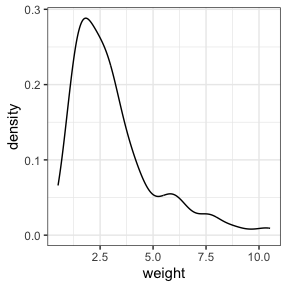

```r
library(ggplot2)

ggplot(fixed_data, aes(x = weight)) +
  geom_density() +
  theme_bw()
```

### Floor or Ceiling Effects

It is also possible to simulate floor or ceiling effects for continuous attributes. This may be of interest in a situation when data are simulated that would be distributed a specific way, but through the measurement process, the scores are truncated by a floor or ceiling value. One common example for the presence of a floor effect is for age, which would start at 0. Ceiling effects could be possible for very easy exams where many individuals may achieve a perfect score, so the ceiling effect would impose this constraint.

```r
sim_arguments <- list(
  formula = y ~ 1 + age + exam,
  fixed = list(age = list(var_type = 'continuous',
                          mean = 6, sd = 1,
                          floor = 5),
               exam = list(var_type = 'continuous',
                           mean = 90, sd = 6,
                           ceiling = 100)),
  sample_size = 50
)

sim_data <- simulate_fixed(data = NULL, sim_arguments)
summary(sim_data$age)
summary(sim_data$exam)
```

[output not shown]

## Ordinal Variable

Ordinal variable specification uses the `sample` function within R to generate ordinal variables that are whole integers. The required argument for these types of variables is `levels`. The `levels` argument takes a range or vector of integer values to be passed to the `sample` function within R. For example, these three specifications for the `levels` argument are valid: `3:60`, `seq(4, 60, 2)`, `c(3, 10, 18, 24, 54, 60)`.

An additional optional argument is `replace`. The `replace` argument specified whether the sampling is done with or without replacement. The default behavior is to do sampling with replacement. If sampling without replacement is desired set `replace = FALSE`. See `sample` for more details on this argument.

Finally, the probability of selecting each value specified to the `levels` argument is also able to be specified through the `prob` argument. If `prob` is specified, it takes a vector of probabilities that must be the same length as the levels argument. The default behavior is for each value specified with `levels` to be equally likely to be sampled.

## Factor Variable

Factor variables are generated similarly to ordinal variables with the `sample` function, however factor variables allow the generation of text or categorical variables in addition to numeric grouping variables. Therefore the only needed argument for factor variables is a vector of numeric or text strings representing the different groups to be generated. For example, both of these specifications are equivalent: `c(1, 2, 3, 4)` and `c('Freshman', 'Sophomore', 'Junior', 'Senior')`. Both of these specifications would generate data for these four groups, the difference is that the text labels will be used when text strings are specified.

An additional optional argument is `replace`. The `replace` argument specified whether the sampling is done with or without replacement. The default behavior is to do sampling with replacement. If sampling without replacement is desired set `replace = FALSE`. See `sample` for more details on this argument.

The probability of selecting each value specified to the `levels` argument is also able to be specified through the `prob` argument. If `prob` is specified, it takes a vector of probabilities that must be the same length as the levels argument. The default behavior is for each value specified with `levels` to be equally likely to be sampled.

### Force Balanced Simulation

It is also possible to simulate data from a balanced factorial design by including the `force_equal = TRUE` argument. This argument will cause the `simulate_fixed()` function to produce a data set with an equal number of observations for each level of the factor variable, instead of randomly sampling from the levels. To see the difference, compare the difference between the two following simulations:

```r
set.seed(321)

sim_arguments <- list(
  formula = y ~ 1 + weight + treat ,
  fixed = list(weight = list(var_type = 'continuous', dist = 'rgamma',
                             shape = 3
                             ),
               treat = list(var_type = 'factor',
                            levels = c('Treatment A', 'Treatment B', 'Control')
                            )
               ),
  sample_size = 33
)

unbalanced_data <- simulate_fixed(data = NULL, sim_arguments)
dplyr::count(unbalanced_data, treat) # unequal number of control and treatment observations
```

```
##         treat  n
## 1 Treatment A 11
## 2 Treatment B  6
## 3     Control 16
```

```r
set.seed(321)

sim_arguments <- list(
  formula = y ~ 1 + weight + treat ,
  fixed = list(weight = list(var_type = 'continuous', dist = 'rgamma',
                             shape = 3
                             ),
               treat = list(var_type = 'factor',
                            levels = c('Treatment A', 'Treatment B', 'Control'),
                            force_equal = TRUE
                            )
               ),
  sample_size = 33
)

balanced_data <- simulate_fixed(data = NULL, sim_arguments)
dplyr::count(balanced_data, treat) # equal number of control and treatment observations
```

```
##         treat  n
## 1 Treatment A 11
## 2 Treatment B 11
## 3     Control 11
```

Note that the `force_equal = TRUE` argument is incompatible with the `replace = FALSE` option. The `force_equal = TRUE` argument supersedes the `prob` argument - in other words, specifying `force_equal = TRUE` as well as specifying specific sampling probabilities will not cause an error, but doesn’t make conceptual sense, and those sampling probabilities will not be reflected in the simulated data.

It is also possible to specify `force_equal = TRUE` when groups are not explicitly equal. In this situation it will get as close to equal as it possibly can, usually within one or two observations of each other. Note, that this will not explicitly retain group size across replications, but they will be within one or two across replications. This behavior would likely be similar across replications than the default approach that would imply the probabilities being equal in the long run.

The following code adjusts the sample size to be 35, which is not equally dividable by 3, the group size. As such, the resulting count of the number of observations within each group is close to being equal.

```r
set.seed(321)

sim_arguments <- list(
  formula = y ~ 1 + weight + treat ,
  fixed = list(weight = list(var_type = 'continuous', dist = 'rgamma',
                             shape = 3
                             ),
               treat = list(var_type = 'factor',
                            levels = c('Treatment A', 'Treatment B', 'Control'),
                            force_equal = TRUE
                            )
               ),
  sample_size = 35
)

balanced_data <- simulate_fixed(data = NULL, sim_arguments)
dplyr::count(balanced_data, treat) # equal number of control and treatment observations
```

```
##         treat  n
## 1 Treatment A 13
## 2 Treatment B 11
## 3     Control 11
```

## Knot Variables

Knot variables are defined as those that are a prominent point based on a specific spot of another variable. A common example of these types of variables would occur in interrupted time series data, where there is a place in time where the treatment is given after a series of baselines. The place where the treatment is given is the knot location.

In simglm, knots are specified within the formula, it is made particularly explicit below with the name: `age_knot`. Adding `_knot` at the end of a knot variable is not needed, but is used here to be more illustrative. When specifying knot attributes, the specific behavior of these attributes are controlled through the `knot` named element of the simulation arguments. See the example below with the simulation arguments for the variable, `age_knot`.

```r
sim_args <- list(
    formula = y ~ 1  + age + age_knot,
    fixed = list(age = list(var_type = 'ordinal', levels = 30:60)),
    knot = list(age_knot = list(variable = 'age',
                                knot_locations = 50)),
    sample_size = 500,
    error = list(variance = 10),
    reg_weights = c(2, .5, 1.5)
  )
```

The required elements to simulate a knot variable is the variable to base the knot location on. This is specified with, `variable = 'age'` above. The second required element is the argument, `knot_locations` which specifies the location where the knot is placed. The knot variable itself is a variable that takes on the number of knot locations plus one, therefore in this example, the `age_knot` variable takes on two values. This would be similar to an indicator or dummy variable used in a linear regression model.

Similar to above, the `simulate_fixed()` function does the simulation of this fixed effect term.

```r
simulate_fixed(data = NULL, sim_args = sim_args) |>
  head()
```

```
##   X.Intercept. age age_knot level1_id
## 1            1  56        1         1
## 2            1  30        0         2
## 3            1  48        0         3
## 4            1  38        0         4
## 5            1  53        1         5
## 6            1  60        1         6
```

As specified, this term would represent a change in the intercept for those that are larger than the knot location, above this was specified as 50 years. More complicated structures can be obtained. One example shown here is that an interaction between the knot variable and the age variable can be made. This term would then represent a change in slope for those that are older than 50. The only change needed is to add this term to the specification within the formula and also add another term to the `reg_weights` argument to specify on average the magnitude of the slope change.

```r
sim_args <- list(
    formula = y ~ 1  + age + age_knot + age:age_knot,
    fixed = list(age = list(var_type = 'ordinal', levels = 30:60)),
    knot = list(age_knot = list(variable = 'age',
                                knot_locations = 50)),
    sample_size = 500,
    error = list(variance = 1000),
    reg_weights = c(2, .5, 1.5, 10)
  )

simulate_fixed(data = NULL, sim_args = sim_args) |>
  head()
```

```
##   X.Intercept. age age_knot age.age_knot level1_id
## 1            1  30        0            0         1
## 2            1  38        0            0         2
## 3            1  33        0            0         3
## 4            1  42        0            0         4
## 5            1  52        1           52         5
## 6            1  40        0            0         6
```

# Random Error Arguments

By default, the random error is generated as random normal with a mean of 0 and standard deviation of 1. If this is the desired behavior, no additional simulation arguments need to be specified in the simulation arguments. For example, the code below generates random error using the fixed arguments already shown above.

```r
set.seed(321)

sim_arguments <- list(
  formula = y ~ 1 + time + weight + age + treat + (1 + time| id),
  fixed = list(time = list(var_type = 'time'),
               weight = list(var_type = 'continuous', mean = 180, sd = 30),
               age = list(var_type = 'ordinal', levels = 30:60, var_level = 2),
               treat = list(var_type = 'factor',
                            levels = c('Treatment', 'Control'),
                            var_level = 2)),
  sample_size = list(level1 = 10, level2 = 20)
)

error_data <- simulate_error(data = NULL, sim_arguments)
head(error_data, n = 20)
```

```
##         error level1_id id
## 1   1.7049032         1  1
## 2  -0.7120386         2  1
## 3  -0.2779849         3  1
## 4  -0.1196490         4  1
## 5  -0.1239606         5  1
## 6   0.2681838         6  1
## 7   0.7268415         7  1
## 8   0.2331354         8  1
## 9   0.3391139         9  1
## 10 -0.5519147        10  1
## 11  0.3477014         1  2
## 12  1.4845918         2  2
## 13  0.1883255         3  2
## 14  2.4432598         4  2
## 15 -1.1534395         5  2
## 16 -0.8046717         6  2
## 17  0.4560691         7  2
## 18  0.4203326         8  2
## 19  0.5775845         9  2
## 20  0.4463561        10  2
```

## Optional Arguments for Random Error

The two main optional arguments for the random error component include a `dist` and `variance` that represent the error generating function and variance of the random error respectively. For example, if a t-distribution is desired for simulation of random error, `dist = 'rt'` can be used to specify the t-distribution as the generating distribution. When distributions other than random normal are specified, it is common that additional arguments will need to be specified for the generating distribution function (i.e. `rt`). In the `rt` example, the `df` argument is needed to specify the degrees of freedom for the t-distribution. Below is an example using a t-distribution.

```r
set.seed(321)

sim_arguments <- list(
  formula = y ~ 1 + time + weight + age + treat + (1 + time| id),
  fixed = list(time = list(var_type = 'time'),
               weight = list(var_type = 'continuous', mean = 180, sd = 30),
               age = list(var_type = 'ordinal', levels = 30:60, var_level = 2),
               treat = list(var_type = 'factor',
                            levels = c('Treatment', 'Control'),
                            var_level = 2)),
  error = list(dist = 'rt', df = 4),
  sample_size = list(level1 = 10, level2 = 20)
)

error_data <- simulate_error(data = NULL, sim_arguments)
head(error_data, n = 20)
```

```
##         error level1_id id
## 1   2.7754417         1  1
## 2  -0.6105358         2  1
## 3   0.2388096         3  1
## 4   0.2364648         4  1
## 5  -0.5580779         5  1
## 6   1.5918703         6  1
## 7   5.3320327         7  1
## 8   0.3197329         8  1
## 9  -0.1541429         9  1
## 10 -1.7929619        10  1
## 11 -1.4292669         1  2
## 12 -1.6045961         2  2
## 13 -1.0007634         3  2
## 14 -1.5413444         4  2
## 15 -0.1818689         5  2
## 16 -1.7195087         6  2
## 17  0.2629315         7  2
## 18  0.8104919         8  2
## 19  0.2150117         9  2
## 20  2.1937363        10  2
```

Finally, the variance of the random error can also be specified to be something other than the default 1. For example, if the variance is desired to be 10, then the argument `variance = 10` will set this variance. This variance works with any distribution function. For example, the following will generate data as a t-distribution with a variance of 10.

```r
set.seed(321)

sim_arguments <- list(
  formula = y ~ 1 + time + weight + age + treat + (1 + time| id),
  fixed = list(time = list(var_type = 'time'),
               weight = list(var_type = 'continuous', mean = 180, sd = 30),
               age = list(var_type = 'ordinal', levels = 30:60, var_level = 2),
               treat = list(var_type = 'factor',
                            levels = c('Treatment', 'Control'),
                            var_level = 2)),
  error = list(dist = 'rt', df = 4, variance = 10),
  sample_size = list(level1 = 10, level2 = 20)
)

error_data <- simulate_error(data = NULL, sim_arguments)
var(error_data$error)
```

```
## [1] 19.36487
```

Note that the variance does not actually equal 10 here. This is due to the generating distribution specified (i.e. t-distribution with 4 degrees of freedom) has a theoretical variance of 2. In cases when the random error has a variance other than 1, the variable needs to be standardized prior to converting to the desired variance value. The standardization can be done in two ways. One, an empirical mean and standard deviation of the generating distribution can be obtained by setting the argument `ther_sim = TRUE`. For example:

```r
set.seed(321)

sim_arguments <- list(
  formula = y ~ 1 + time + weight + age + treat + (1 + time| id),
  fixed = list(time = list(var_type = 'time'),
               weight = list(var_type = 'continuous', mean = 180, sd = 30),
               age = list(var_type = 'ordinal', levels = 30:60, var_level = 2),
               treat = list(var_type = 'factor',
                            levels = c('Treatment', 'Control'),
                            var_level = 2)),
  error = list(dist = 'rt', df = 4, variance = 10, ther_sim = TRUE),
  sample_size = list(level1 = 10, level2 = 20)
)

error_data <- simulate_error(data = NULL, sim_arguments)
var(error_data$error)
```

```
## [1] 6.893405
```

This simulation takes longer to run as the generated empirical mean and standard deviation for the standardization draws a large number of random values from the specified distribution. To speed up this process, the theoretical values can be specified directly within the `ther_val` argument as a vector with the mean specified first followed by the standard deviation. This is shown below:

```r
set.seed(321)

sim_arguments <- list(
  formula = y ~ 1 + time + weight + age + treat + (1 + time| id),
  fixed = list(time = list(var_type = 'time'),
               weight = list(var_type = 'continuous', mean = 180, sd = 30),
               age = list(var_type = 'ordinal', levels = 30:60, var_level = 2),
               treat = list(var_type = 'factor',
                            levels = c('Treatment', 'Control'),
                            var_level = 2)),
  error = list(dist = 'rt', df = 4, variance = 10, ther_val = c(0, sqrt(2))),
  sample_size = list(level1 = 10, level2 = 20)
)

error_data <- simulate_error(data = NULL, sim_arguments)
var(error_data$error)
```

```
## [1] 9.682433
```

## Heterogeneity of Variance

It is also possible to generate heterogeneity of variance for the random error.

```r
simulation_arguments <- list(
  formula = y ~ 1 + group,
  fixed = list(group = list(var_type = 'factor',
                            levels = c('male', 'female'))),
  sample_size = 500,
  error = list(variance = 1),
  heterogeneity = list(variable = 'group',
                       variance = c(1, 8)),
  reg_weights = c(0, .15)
)

hetero_data <- simulate_fixed(data = NULL, simulation_arguments) |>
  simulate_error(simulation_arguments) |>
  simulate_heterogeneity(simulation_arguments)
```

```r
hetero_data |>
  group_by(group) |>
  summarise(var_error = var(error),
            var_o_error = var(orig_error))
```

```
## # A tibble: 2 × 3
##   group  var_error var_o_error
##   <fct>      <dbl>       <dbl>
## 1 male        1.08        1.08
## 2 female      8.25        1.03
```

# Random Effect Arguments

The random effect arguments are passed through a named element of the list to the simulation arguments called ‘randomeffect’. Within this element, each random effect specified in the formula must be specified as a named list. The named list allows the user to specify the names that will be used in the data simulation for the random effects. The default behavior of these random effects is to be simulated from a random normal distribution with mean 0 and variance of 1.

Many of the same arguments that have been discussed with the error simulation are possible for the random effect simulation arguments. These include: `dist`, `variance`, `ther_sim`, `ther_val` and other arguments that are needed to pass on the data generating function. In addition, the argument `var_level` first introduced with the fixed effects are present here indicating which level of the data structure the random effect should be generated at. These arguments will not be discussed in more detail here, but readers can see examples of these arguments within the fixed effects and random error sections above.

Below is an example that simulated two random effects in a two-level nested model and specifies the variance of 8 and 3 for the two random effects respectively. Finally, you will notice in the final output, the names of the random effect columns are specified by the names included in the list associated with the “randomeffect” portion of the simulation arguments.

```r
set.seed(321)

sim_arguments <- list(
  formula = y ~ 1 + time + weight + age + treat + (1 + time| id),
  fixed = list(time = list(var_type = 'time'),
               weight = list(var_type = 'continuous', mean = 180, sd = 30),
               age = list(var_type = 'ordinal', levels = 30:60, var_level = 2),
               treat = list(var_type = 'factor',
                            levels = c('Treatment', 'Control'),
                            var_level = 2)),
  randomeffect = list(int_id = list(variance = 8, var_level = 2),
                time_id = list(variance = 3, var_level = 2)),
  sample_size = list(level1 = 10, level2 = 20)
)

random_data <- simulate_randomeffect(data = NULL, sim_arguments)
head(random_data, n = 20)
```

```
##       int_id   time_id level1_id id
## 1   4.822195  1.588733         1  1
## 2   4.822195  1.588733         2  1
## 3   4.822195  1.588733         3  1
## 4   4.822195  1.588733         4  1
## 5   4.822195  1.588733         5  1
## 6   4.822195  1.588733         6  1
## 7   4.822195  1.588733         7  1
## 8   4.822195  1.588733         8  1
## 9   4.822195  1.588733         9  1
## 10  4.822195  1.588733        10  1
## 11 -2.013949 -0.185436         1  2
## 12 -2.013949 -0.185436         2  2
## 13 -2.013949 -0.185436         3  2
## 14 -2.013949 -0.185436         4  2
## 15 -2.013949 -0.185436         5  2
## 16 -2.013949 -0.185436         6  2
## 17 -2.013949 -0.185436         7  2
## 18 -2.013949 -0.185436         8  2
## 19 -2.013949 -0.185436         9  2
## 20 -2.013949 -0.185436        10  2
```

## Multiple Membership Random Effects

If multiple membership random effects are desired, these can be specified directly within the formula syntax as you would with lme4. For example, `y ~ 1 + time + weight + age + treat + (1 + time| id) + (1 | neighborhood_id)`. When documenting the simulation arguments for the additional multiple membership random effect (i.e. `(1 | neighborhood_id)`), specifying `multiple_member = TRUE` with that random effect to identify that this is indeed a multiple membership random effect. Secondly, you can also specify directly the number of clusters that are associated with this multiple membership factor, this can be different than those specified in the `sample_size` argument. This can be done with the `num_ids` argument. Below is an example with a single multiple membership random effect representing neighborhoods individuals belong in

```r
set.seed(321)

sim_arguments <- list(
  formula = y ~ 1 + time + weight + age + treat + (1 + time| id) +
    (1 | neighborhood_id),
  fixed = list(time = list(var_type = 'time'),
               weight = list(var_type = 'continuous', mean = 180, sd = 30),
               age = list(var_type = 'ordinal', levels = 30:60, var_level = 2),
               treat = list(var_type = 'factor',
                            levels = c('Treatment', 'Control'),
                            var_level = 2)),
  randomeffect = list(int_id = list(variance = 8, var_level = 2),
                time_id = list(variance = 3, var_level = 2),
                int_nid = list(variance = 5, var_level = 2,
                               multiple_member = TRUE,
                               num_ids = 12)),
  sample_size = list(level1 = 10, level2 = 20)
)

random_data <- simulate_randomeffect(data = NULL, sim_arguments)
head(random_data, n = 20)
```

```
##       int_id   time_id    int_nid neighborhood_id level1_id id
## 1   4.822195  1.588733  0.7319884               1         1  1
## 2   4.822195  1.588733  0.7319884               1         2  1
## 3   4.822195  1.588733  0.7319884               1         3  1
## 4   4.822195  1.588733  0.7319884               1         4  1
## 5   4.822195  1.588733  0.7319884               1         5  1
## 6   4.822195  1.588733  0.7319884               1         6  1
## 7   4.822195  1.588733  0.7319884               1         7  1
## 8   4.822195  1.588733  0.7319884               1         8  1
## 9   4.822195  1.588733  0.7319884               1         9  1
## 10  4.822195  1.588733  0.7319884               1        10  1
## 11 -2.013949 -0.185436  0.7319884               1         1  2
## 12 -2.013949 -0.185436  0.7319884               1         2  2
## 13 -2.013949 -0.185436  0.7319884               1         3  2
## 14 -2.013949 -0.185436  0.7319884               1         4  2
## 15 -2.013949 -0.185436  0.7319884               1         5  2
## 16 -2.013949 -0.185436  0.7319884               1         6  2
## 17 -2.013949 -0.185436 -5.0111674               2         7  2
## 18 -2.013949 -0.185436 -5.0111674               2         8  2
## 19 -2.013949 -0.185436 -5.0111674               2         9  2
## 20 -2.013949 -0.185436 -5.0111674               2        10  2
```

# Correlated Fixed and Random Effects

Data attributes are often correlated, therefore, in order to really mimic real-world data, simulated data that are correlated would be desired. This can be done with `simglm` by using the function `correlated_variables()`. This function processes a new set of simulation arguments specified with the named `correlate`. In what follows, discussion of correlating fixed effects will be explored first, followed by correlating random effects next.

## Fixed Effect Correlation

```r
sim_args <- list(formula = y ~ 1 + act + gpa + commute_time,
                 fixed = list(act = list(var_type = 'ordinal',
                                         levels = 15:36),
                              gpa = list(var_type = 'continuous',
                                         mean = 2,
                                         sd = .5),
                              commute_time = list(var_type = 'continuous',
                                         mean = 15,
                                         sd = 6)),
                 correlate = list(fixed = data.frame(x = c('act', 'act', 'gpa'),
                                                     y = c('gpa', 'commute_time', 'commute_time'),
                                                     corr = c(0.5, .6, .2))),
                 sample_size = 1000)

correlate_attribute <- simulate_fixed(data = NULL, sim_args) |>
  correlate_variables(sim_args)

head(correlate_attribute)
```

```
##   X.Intercept. act_old  gpa_old commute_time_old level1_id act_corr      gpa
## 1            1      31 2.542058         19.84992         1 22.84891 1.646131
## 2            1      30 1.094168         11.30912         2 16.22560 1.825208
## 3            1      31 1.824700         13.73815         3 19.10715 1.853173
## 4            1      16 1.573188         15.26606         4 31.55381 2.137908
## 5            1      20 1.344491         19.25067         5 26.71471 1.654872
## 6            1      16 1.389140         15.84091         6 30.60086 2.038347
##   commute_time act
## 1     7.174773  23
## 2    16.554488  16
## 3    11.424758  19
## 4    24.990913  32
## 5    23.118977  27
## 6    26.079270  31
```

```r
select(correlate_attribute, -X.Intercept., -level1_id) |>
  cor()
```

```
##                      act_old     gpa_old commute_time_old    act_corr
## act_old           1.00000000  0.04962541       0.04835660 -0.91236220
## gpa_old           0.04962541  1.00000000      -0.04152076  0.36359176
## commute_time_old  0.04835660 -0.04152076       1.00000000 -0.05906384
## act_corr         -0.91236220  0.36359176      -0.05906384  1.00000000
## gpa              -0.42797012  0.33034468      -0.86681668  0.53201958
## commute_time     -0.87475571 -0.52737640      -0.02190753  0.59972433
## act              -0.91589813  0.34370587      -0.06320982  0.99513233
##                         gpa commute_time         act
## act_old          -0.4279701  -0.87475571 -0.91589813
## gpa_old           0.3303447  -0.52737640  0.34370587
## commute_time_old -0.8668167  -0.02190753 -0.06320982
## act_corr          0.5320196   0.59972433  0.99513233
## gpa               1.0000000   0.20455897  0.53062581
## commute_time      0.2045590   1.00000000  0.61238459
## act               0.5306258   0.61238459  1.00000000
```

## Random Effect Correlation

```r
sim_args <- list(formula = y ~ 1 + act + gpa + sat + (1 + act | id),
                 fixed = list(act = list(var_type = 'continuous',
                                         mean = 20,
                                         sd = 4),
                              gpa = list(var_type = 'continuous',
                                         mean = 2,
                                         sd = .5),
                              sat = list(var_type = 'continuous',
                                         mean = 500,
                                         sd = 100)),

                 randomeffect = list(int_id = list(variance = 8, var_level = 2),
                                     act_id = list(variance = 3, var_level = 2)),
                 sample_size = list(level1 = 100, level2 = 5000),
                 correlate = list(random = data.frame(x = 'int_id', y = 'act_id',
                                                      corr = .3))
                 )

random_correlate <- simulate_randomeffect(data = NULL, sim_args) |>
  correlate_variables(sim_args)

head(random_correlate)
```

```
##   int_id_old act_id_old level1_id id   int_id   act_id
## 1  -5.137806  -2.204438         1  1 4.540962 3.362763
## 2  -5.137806  -2.204438         2  1 4.540962 3.362763
## 3  -5.137806  -2.204438         3  1 4.540962 3.362763
## 4  -5.137806  -2.204438         4  1 4.540962 3.362763
## 5  -5.137806  -2.204438         5  1 4.540962 3.362763
## 6  -5.137806  -2.204438         6  1 4.540962 3.362763
```

```r
select(random_correlate, -level1_id, -id) |>
  cor()
```

```
##              int_id_old   act_id_old     int_id     act_id
## int_id_old  1.000000000  0.001196824 -0.9888210 -0.4418334
## act_id_old  0.001196824  1.000000000  0.1479240 -0.8976253
## int_id     -0.988820977  0.147924047  1.0000000  0.3031302
## act_id     -0.441833443 -0.897625255  0.3031302  1.0000000
```

# Unbalanced level 2 and 3 designs

Often it is of interest to not have the same number of observations within each cluster when simulated data that are clustered. For example, imagine a situation within education where there are students nested in classrooms which are nested in schools. You could build this example further, but for this example, suppose this is the hierarchy that is of interest to model. In most situations, the number of classrooms and the number of students within those classrooms would not be the same. Instead, it is most likely that the number of classrooms would vary across schools and the number of students would vary across classrooms within the same school.

To be very explicit, one school may have 15 classrooms, another may have 35 classrooms, and another could have 100 classrooms. Within the school with 15 classrooms, the classrooms may average 20 students in each, but may vary between 15 to 25 students across all 15 classrooms. This is important to simulate to mimic real world data that would be collected.

## Unbalanced Level 2 Example

Suppose only students and classrooms are focused on first. To generate realistic situations, it is of interest to vary the number of students within each classroom. To do this, the `runif()` function can be used to generate random numbers between specified minimum and maximum classroom sizes. A user can also specify the values directly in a vector of samples sizes that are the same size as the number of level 2 units (classrooms here).

```r
set.seed(38)

level1_ss <- runif(15, min = 14, max = 30) |>
  round(0)
level1_ss
```

```
##  [1] 20 14 16 20 26 26 22 21 15 28 15 22 25 20 22
```

The “level1_ss” vector are whole integers representing the sample size for each classroom. Below, these data are simulated. Notice that the “level1_ss” object is passed as an element of the level one sample size. Finally, a count of the number of observations in each classroom are shown, notice how these are the same as the values in the “level1_ss” object.

```r
sim_arguments <- list(
  formula = test_scores ~ 1 + gpa + (1 | classroom),
  fixed = list(
    gpa = list(var_type = 'continuous', mean = 3, sd = 0.5,
               ceiling = 4, floor = 0)
  ),
  random = list(
    classroom_int = list(variance = 2, var_level = 2)
  ),
  error = list(variance = 5),
  reg_weights = c(50, 0.5),
  sample_size = list(
    level1 = level1_ss,
    level2 = 15
  )
)

simulate_fixed(data = NULL, sim_arguments) |>
  dplyr::count(classroom)
```

```
##    classroom  n
## 1          1 20
## 2          2 14
## 3          3 16
## 4          4 20
## 5          5 26
## 6          6 26
## 7          7 22
## 8          8 21
## 9          9 15
## 10        10 28
## 11        11 15
## 12        12 22
## 13        13 25
## 14        14 20
## 15        15 22
```

## Unbalanced Level 3 Example

This can be further specified to work with the full level 3 example discussed above with students nested within classrooms which are nested in schools. Suppose there are 25 schools that are included in the sample frame. Within these 25 schools, suppose there are between 8 and 50 classrooms.

```r
set.seed(34)

level2_ss <- runif(25, min = 8, max = 50) |>
  round(0)
level2_ss
```

```
##  [1] 27 50 45 18 18 44 20 38 25 32 22 26 39 10 16 42 44  9 29 29 22 45 40 17 26
```

Each number for the level 2 sample size object represents the number of classrooms that are in each of the 25 schools. For example, the first number above, 27, is the number of classrooms in the first school. Once the unbalanced level 2 sample size is specified, then, the level 1 sample size for each classroom can be generated. To generate the level 1 sample size, we need the **sum** of the level 2 sample sizes. That is, we need to generate a sample size for **each** of the 27 classrooms for the first school and so on. Therefore, a total of 733 sample sizes will need to be generated as that is the total number of classrooms simulated across all 25 schools. Suppose that each classroom ranges from 12 to 28 students.

```r
level1_ss <- runif(sum(level2_ss), min = 12, max = 28) |>
  round(0)
head(level1_ss)
```

```
## [1] 27 26 24 22 21 27
```

The sample size for the first six classrooms are shown. These could now be specified within the simulation arguments to extend the code generated in the level 2 example.

```r
sim_arguments <- list(
  formula = test_scores ~ 1 + gpa + (1 | classroom) + (1 | school),
  fixed = list(
    gpa = list(var_type = 'continuous', mean = 3, sd = 0.5,
               ceiling = 4, floor = 0)
  ),
  randomeffect = list(
    classroom_int = list(variance = 2, var_level = 2),
    school_int = list(variance = 0.5, var_level = 3)
  ),
  error = list(variance = 5),
  reg_weights = c(50, 0.5),
  sample_size = list(
    level1 = level1_ss,
    level2 = level2_ss,
    level3 = 25
  )
)

simulate_fixed(data = NULL, sim_arguments) |>
  dplyr::count(school, classroom) |>
  head()
```

```
##   school classroom  n
## 1      1         1 27
## 2      1         2 26
## 3      1         3 24
## 4      1         4 22
## 5      1         5 21
## 6      1         6 27
```

The sample sizes for the first 6 classrooms for the first school are shown. These values will match the level1_ss object shown above.

# Missing Data Arguments

Missing data is the standard rather than the exception in real world data. Therefore, generating data that include missing is important for generating data that are representative of real world data. In the power analysis context, most power analyses do not include missing data in the power computations (particularly if these are closed form solutions), but power can be negatively affected by missing data.

Fortunatly, the simglm package contains many useful frameworks for generating missing data. To generate missing data, the `generate_missing` function can be used for this. This function is called after the complete data are generated. This means that the complete data and missing data will be generated. Currently three types of missing data are supported, dropout, random, and mar (missing at random). The specification of missing data arguments is done using a named element to the simulation argument list called “missing_data”.

## Random Missing Data

First, lets explore random missing data. This structure is equivalent to the missing completely at random framework if you are familiar with Rubin’s missing data classifications. To generate random missing data the `type = 'random'` is specified. Two additional arguments are needed to generate the missing data, first the missing proportion needs to be specified with `miss_prop` and the name of the new response variable with missing data needs to be specified with `new_outcome`. Below is an example generating data with random missing data.

```r
set.seed(321)

sim_arguments <- list(
  formula = y ~ 1 + time + weight + age + treat + (1 + time| id),
  reg_weights = c(4, 0.5, 0.75, 0, 0.33),
  fixed = list(time = list(var_type = 'time'),
               weight = list(var_type = 'continuous', mean = 180, sd = 30),
               age = list(var_type = 'ordinal', levels = 30:60, var_level = 2),
               treat = list(var_type = 'factor',
                            levels = c('Treatment', 'Control'),
                            var_level = 2)),
  randomeffect = list(int_id = list(variance = 8, var_level = 2),
                      time_id = list(variance = 3, var_level = 2)),
  missing_data = list(miss_prop = .25, new_outcome = 'y_missing',
                      type = 'random'),
  sample_size = list(level1 = 10, level2 = 20)
)

data_w_missing <- simulate_fixed(data = NULL, sim_arguments) |>
  simulate_randomeffect(sim_arguments) |>
  simulate_error(sim_arguments) |>
  generate_response(sim_arguments) |>
  generate_missing(sim_arguments)

head(data_w_missing, n = 10)
```

```
##    X.Intercept. time   weight age treat_1   treat level1_id id    int_id
## 1             1    0 231.1471  39       1 Control         1  1 0.2244243
## 2             1    1 158.6388  39       1 Control         2  1 0.2244243
## 3             1    2 171.6605  39       1 Control         3  1 0.2244243
## 4             1    3 176.4105  39       1 Control         4  1 0.2244243
## 5             1    4 176.2812  39       1 Control         5  1 0.2244243
## 6             1    5 188.0455  39       1 Control         6  1 0.2244243
## 7             1    6 201.8052  39       1 Control         7  1 0.2244243
## 8             1    7 186.9941  39       1 Control         8  1 0.2244243
## 9             1    8 190.1734  39       1 Control         9  1 0.2244243
## 10            1    9 163.4426  39       1 Control        10  1 0.2244243
##     time_id        error fixed_outcome random_effects        y miss_prob
## 1  2.533554  2.382697049      177.6903      0.2244243 180.2974     0.646
## 2  2.533554 -0.319179378      123.8091      2.7579779 126.2479     0.088
## 3  2.533554  0.716756305      134.0753      5.2915315 140.0836     0.534
```

[output cut: 18 more lines]

We can look at the amount of missing data:

```r
prop.table(table(is.na(data_w_missing$y_missing)))
```

```
##
## FALSE  TRUE
## 0.735 0.265
```

## MAR Missing Data

Data that are missing at random (MAR) can be generated as well.

```r
set.seed(321)

sim_arguments <- list(
  formula = y ~ 1 + time + weight + age + treat + (1 + time| id),
  reg_weights = c(4, 0.5, 0.75, 0, 0.33),
  fixed = list(time = list(var_type = 'time'),
               weight = list(var_type = 'continuous', mean = 180, sd = 30,
                             var_level = 1),
               age = list(var_type = 'ordinal', levels = 30:60, var_level = 2),
               treat = list(var_type = 'factor',
                            levels = c('Treatment', 'Control'),
                            var_level = 2)),
  randomeffect = list(int_id = list(variance = 8, var_level = 2),
                      time_id = list(variance = 3, var_level = 2)),
  missing_data = list(new_outcome = 'y_missing', miss_cov = 'weight',
                      mar_prop = seq(from = 0, to = .9, length.out = 200),
                      type = 'mar'),
  sample_size = list(level1 = 10, level2 = 20)
)

data_w_missing <- simulate_fixed(data = NULL, sim_arguments) |>
  simulate_randomeffect(sim_arguments) |>
  simulate_error(sim_arguments) |>
  generate_response(sim_arguments) |>
  generate_missing(sim_arguments)

head(data_w_missing, n = 10)
```

```
##    X.Intercept. time   weight age treat_1   treat level1_id id    int_id
## 1             1    0 231.1471  39       1 Control         1  1 0.2244243
## 2             1    1 158.6388  39       1 Control         2  1 0.2244243
## 3             1    2 171.6605  39       1 Control         3  1 0.2244243
## 4             1    3 176.4105  39       1 Control         4  1 0.2244243
## 5             1    4 176.2812  39       1 Control         5  1 0.2244243
## 6             1    5 188.0455  39       1 Control         6  1 0.2244243
## 7             1    6 201.8052  39       1 Control         7  1 0.2244243
## 8             1    7 186.9941  39       1 Control         8  1 0.2244243
## 9             1    8 190.1734  39       1 Control         9  1 0.2244243
## 10            1    9 163.4426  39       1 Control        10  1 0.2244243
##     time_id        error fixed_outcome random_effects        y miss_prop
## 1  2.533554  2.382697049      177.6903      0.2244243 180.2974 0.8683417
## 2  2.533554 -0.319179378      123.8091      2.7579779 126.2479 0.2035176
## 3  2.533554  0.716756305      134.0753      5.2915315 140.0836 0.3165829
```

[output cut: 18 more lines]

We can look at the amount of missing data:

```r
prop.table(table(is.na(data_w_missing$y_missing)))
```

```
##
## FALSE  TRUE
##  0.54  0.46
```

## Dropout Missing Data

Dropout missing data is possible when simulating data from a longitudinal design. When requesting dropout missing data, observations are removed after a specific point in the time cycle. For example, perhaps an individual stops being a part of the study after the third measurement. To request this type of missing data, the `type = 'dropout'` can be specified. In addition, one new argument is needed, `clust_var`. This argument represents the id associated with the clusters with longitudinal data. Below is an example:

```r
set.seed(321)

sim_arguments <- list(
  formula = y ~ 1 + time + weight + age + treat + (1 + time| id),
  reg_weights = c(4, 0.5, 0.75, 0, 0.33),
  fixed = list(time = list(var_type = 'time'),
               weight = list(var_type = 'continuous', mean = 180, sd = 30),
               age = list(var_type = 'ordinal', levels = 30:60, var_level = 2),
               treat = list(var_type = 'factor',
                            levels = c('Treatment', 'Control'),
                            var_level = 2)),
  randomeffect = list(int_id = list(variance = 8, var_level = 2),
                      time_id = list(variance = 3, var_level = 2)),
  missing_data = list(miss_prop = .25, new_outcome = 'y_missing',
                      clust_var = 'id', type = 'dropout'),
  sample_size = list(level1 = 10, level2 = 20)
)

data_w_missing <- simulate_fixed(data = NULL, sim_arguments) |>
  simulate_randomeffect(sim_arguments) |>
  simulate_error(sim_arguments) |>
  generate_response(sim_arguments) |>
  generate_missing(sim_arguments)

head(data_w_missing, n = 10)
```

```
##    X.Intercept. time   weight age treat_1   treat level1_id id    int_id
## 1             1    0 231.1471  39       1 Control         1  1 0.2244243
## 2             1    1 158.6388  39       1 Control         2  1 0.2244243
## 3             1    2 171.6605  39       1 Control         3  1 0.2244243
## 4             1    3 176.4105  39       1 Control         4  1 0.2244243
## 5             1    4 176.2812  39       1 Control         5  1 0.2244243
## 6             1    5 188.0455  39       1 Control         6  1 0.2244243
## 7             1    6 201.8052  39       1 Control         7  1 0.2244243
## 8             1    7 186.9941  39       1 Control         8  1 0.2244243
## 9             1    8 190.1734  39       1 Control         9  1 0.2244243
## 10            1    9 163.4426  39       1 Control        10  1 0.2244243
##     time_id        error fixed_outcome random_effects        y missing
## 1  2.533554  2.382697049      177.6903      0.2244243 180.2974       0
## 2  2.533554 -0.319179378      123.8091      2.7579779 126.2479       0
## 3  2.533554  0.716756305      134.0753      5.2915315 140.0836       0
```

[output cut: 18 more lines]

We can look at the amount of missing data:

```r
prop.table(table(is.na(data_w_missing$y_missing)))
```

```
##
## FALSE  TRUE
## 0.945 0.055
```

We can also look now at the amount of missing by the time variable.

```r
prop.table(table(is.na(data_w_missing$y_missing), data_w_missing$time))
```

```
##
##             0     1     2     3     4     5     6     7     8     9
##   FALSE 0.100 0.100 0.100 0.100 0.095 0.090 0.090 0.090 0.090 0.090
##   TRUE  0.000 0.000 0.000 0.000 0.005 0.010 0.010 0.010 0.010 0.010
```

### Specify location of dropout

If additional control is desired, specifying the location of the dropout is possible. In this situation, a vector is passed to `dropout_location` that specifies for each individual (more generally each level 2 unit) where the dropout occurs. Below is an example of this.

```r
set.seed(321)

sim_arguments <- list(
  formula = y ~ 1 + time + weight + age + treat + (1 + time| id),
  reg_weights = c(4, 0.5, 0.75, 0, 0.33),
  fixed = list(time = list(var_type = 'time'),
               weight = list(var_type = 'continuous', mean = 180, sd = 30),
               age = list(var_type = 'ordinal', levels = 30:60, var_level = 2),
               treat = list(var_type = 'factor',
                            levels = c('Treatment', 'Control'),
                            var_level = 2)),
  randomeffect = list(int_id = list(variance = 8, var_level = 2),
                      time_id = list(variance = 3, var_level = 2)),
  missing_data = list(new_outcome = 'y_missing',
      dropout_location = c(3, 9, 1, 6, 7, 8, 6, 9, 2, 4, 6, 5, 8, 9, 4, 5,
                           6, 7, 2, 9),
                      clust_var = 'id', type = 'dropout'),
  sample_size = list(level1 = 10, level2 = 20)
)

data_w_missing <- simulate_fixed(data = NULL, sim_arguments) |>
  simulate_randomeffect(sim_arguments) |>
  simulate_error(sim_arguments) |>
  generate_response(sim_arguments) |>
  generate_missing(sim_arguments)

head(data_w_missing, n = 10)
```

```
##    X.Intercept. time   weight age treat_1   treat level1_id id    int_id
## 1             1    0 231.1471  39       1 Control         1  1 0.2244243
## 2             1    1 158.6388  39       1 Control         2  1 0.2244243
## 3             1    2 171.6605  39       1 Control         3  1 0.2244243
## 4             1    3 176.4105  39       1 Control         4  1 0.2244243
## 5             1    4 176.2812  39       1 Control         5  1 0.2244243
## 6             1    5 188.0455  39       1 Control         6  1 0.2244243
## 7             1    6 201.8052  39       1 Control         7  1 0.2244243
## 8             1    7 186.9941  39       1 Control         8  1 0.2244243
## 9             1    8 190.1734  39       1 Control         9  1 0.2244243
## 10            1    9 163.4426  39       1 Control        10  1 0.2244243
##     time_id        error fixed_outcome random_effects        y missing
## 1  2.533554  2.382697049      177.6903      0.2244243 180.2974       0
## 2  2.533554 -0.319179378      123.8091      2.7579779 126.2479       0
## 3  2.533554  0.716756305      134.0753      5.2915315 140.0836       1
```

[output cut: 18 more lines]

We can look at the amount of missing data:

```r
prop.table(table(is.na(data_w_missing$y_missing)))
```

```
##
## FALSE  TRUE
##  0.48  0.52
```

We can also look now at the amount of missing by the time variable.

```r
prop.table(table(is.na(data_w_missing$y_missing), data_w_missing$time))
```

```
##
##             0     1     2     3     4     5     6     7     8     9
##   FALSE 0.095 0.085 0.080 0.070 0.060 0.040 0.030 0.020 0.000 0.000
##   TRUE  0.005 0.015 0.020 0.030 0.040 0.060 0.070 0.080 0.100 0.100
```

# Model Fit Arguments

The default behavior when fitting models to the generated data is to fit a model with the same formula as the generated data (i.e. `formula` simulation arguments). Secondly, the default model functions are `lm`/`glm` for single level simulation and `lmer`/`glmer` for multilevel simulation. Finally, the default regression weights specified in `reg_weights` are to compute statistics for power, type I error rates, and precision.

These defaults can be overriden by specifying simulation arguments through the named list called `model_fit`. Some examples were given in the Tidy Simulation vignette and the options that are able to be specified will depend on the model fitting function specified. A few examples are given for various model types, however, the user is directed to the documentation of the modeling functions specified through the `model_function` argument.

## Changing Family Argument

For GLM models, users may wish to directly specify the family argument or change the link function within a specific family. For example, when generating data with a binary dependent variable, the logistic or probit links could be used when specifying the binomial family. Below is an example of using the binomial family with a logit link (the default link function).

```r
set.seed(321)

sim_arguments <- list(
  formula = y ~ 1 + weight + age + sex,
  fixed = list(weight = list(var_type = 'continuous', mean = 0, sd = 30),
               age = list(var_type = 'ordinal', levels = 0:30),
               sex = list(var_type = 'factor', levels = c('male', 'female'))),
  error = list(variance = 25),
  sample_size = 10,
  reg_weights = c(2, 0.3, -0.1, 0.5),
  outcome_type = 'binary',
  model_fit = list(
    model_function = 'glm',
    family = binomial
  )
)

tmp_data <- simulate_fixed(data = NULL, sim_arguments) |>
  simulate_error(sim_arguments) |>
  generate_response(sim_arguments) |>
  model_fit(sim_arguments)
tmp_data$family
```

```
##
## Family: binomial
## Link function: logit
```

The link function could then be changed to a probit link function with the following code:

```r
set.seed(321)

sim_arguments <- list(
  formula = y ~ 1 + weight + age + sex,
  fixed = list(weight = list(var_type = 'continuous', mean = 0, sd = 30),
               age = list(var_type = 'ordinal', levels = 0:30),
               sex = list(var_type = 'factor', levels = c('male', 'female'))),
  error = list(variance = 25),
  sample_size = 10,
  reg_weights = c(2, 0.3, -0.1, 0.5),
  outcome_type = 'binary',
  model_fit = list(
    model_function = 'glm',
    family = binomial(link = 'probit')
  )
)

tmp_data <- simulate_fixed(data = NULL, sim_arguments) |>
  simulate_error(sim_arguments) |>
  generate_response(sim_arguments) |>
  model_fit(sim_arguments)
tmp_data$family
```

```
##
## Family: binomial
## Link function: probit
```

## Adding Serial Correlation

To come…

## Marginal Models

It is also possible to change the default model fitting functions. For example, an alternative model approach to mixed models is generalized estimating equations (GEE) or marginal models. One implementation of these models in R is the geepack package. Below is the code to fit a marginal model in a longitudinal context. The code is not evaluated, so no coefficients are shown, but if you have the `geepack` package installed, this code should run as written.

```r
set.seed(321)

# To-DO: Add knot variable and debug

sim_arguments <- list(
  formula = y ~ 1 + time + weight + age + treat + (1 + time| id),
  fixed = list(time = list(var_type = 'time',
                           time_levels = c(0, 0.5, 1, 1.5, 2, 2.5, 3, 4, 5, 6)),
               weight = list(var_type = 'continuous', mean = 0, sd = 30),
               age = list(var_type = 'ordinal', levels = 0:30, var_level = 2),
               treat = list(var_type = 'factor',
                            levels = c('Treatment', 'Control'),
                            var_level = 2)),
  reg_weights = c(0.4, 0.2, -0.5, 1, -0.6),
  randomeffect = list(int_id = list(variance = 8, var_level = 2),
                time_id = list(variance = 3, var_level = 2)),
  error = list(variance = 5),
  outcome_type = 'binary',
  sample_size = list(level1 = 10, level2 = 20),
  model_fit = list(
    model_function = geepack::geeglm,
    formula = y ~ 1 + time + weight + age + treat,
    id = 'level1_id',
    family = binomial,
    corstr = 'ar1'
  )
)

simulate_fixed(data = NULL, sim_arguments) |>
  simulate_error(sim_arguments) |>
  simulate_randomeffect(sim_arguments) |>
  generate_response(sim_arguments) |>
  model_fit(sim_arguments) |>
  extract_coefficients()
```

# Vary Simulation Arguments

The `replicate_simulation` function first shown in the “tidy_simulation” vignette, can directly allow for the varying of simulation arguments. In order to vary simulation arguments, an additional named list called `vary_arguments` can be added to the simulation arguments passed to the functions. The `vary_arguments` elements of the simulation arguments is a nested named list. Within the named list, the arguments that are wished to be varied are specified by name. For example, a common argument varied is sample size. The following example varies the sample size to return multiple simulated data sets with different sample sizes.

Note: A user would likely want to change `plan(sequential)` to something like `plan(mutisession)` or `plan(multicore)` to run these in parallel. `plan(sequential)` is used here for vignette processing.

```r
library(future)
plan(sequential)

sim_arguments <- list(
  formula =  resp_var ~ 1 + time + factor(trt) + time:factor(trt) +
    (1 + time | individual),
  reg_weights = c(4, 0.5, 0.75, 0),
  fixed = list(time = list(var_type = 'time'),
               trt = list(var_type = 'factor', levels = c('Drug', 'Placebo'),
                          var_level = 2)
               ),
  randomeffect = list(int_clust = list(variance = .2, var_level = 2),
                      time_clust = list(variance = .3, var_level = 2)),
  replications = 3,
  error = list(variance = 1),
  vary_arguments = list(
    sample_size = list(list(level1 = 5, level2 = 50),
                       list(level1 = 5, level2 = 60))
  )
)

replicate_simulation(sim_arguments)
```

```
## [[1]]
##                       sample_size replication X.Intercept. time trt_1
## 1   list(level1 = 5, level2 = 50)           1            1    0     1
## 2   list(level1 = 5, level2 = 50)           1            1    1     1
## 3   list(level1 = 5, level2 = 50)           1            1    2     1
## 4   list(level1 = 5, level2 = 50)           1            1    3     1
## 5   list(level1 = 5, level2 = 50)           1            1    4     1
## 6   list(level1 = 5, level2 = 50)           1            1    0     1
## 7   list(level1 = 5, level2 = 50)           1            1    1     1
## 8   list(level1 = 5, level2 = 50)           1            1    2     1
## 9   list(level1 = 5, level2 = 50)           1            1    3     1
## 10  list(level1 = 5, level2 = 50)           1            1    4     1
## 11  list(level1 = 5, level2 = 50)           1            1    0     1
## 12  list(level1 = 5, level2 = 50)           1            1    1     1
## 13  list(level1 = 5, level2 = 50)           1            1    2     1
```

[output cut: 4944 more lines]

## Varying Arguments to Compute Power